# Data Explore

## Summary

This RMD explains data explore and prepration steps for further modeling.

The datasets used in this application are available under following link:

https://d396qusza40orc.cloudfront.net/dsscapstone/dataset/Coursera-SwiftKey.zip

Following files and scripts are created as part of buidling this text mining application.

**Load Packages**

```r
Packages <- c("qdap", "tm" ,"wordcloud", "ggplot2", "ggthemes", "RWeka", "tidytext")
lapply(Packages, library, character.only = TRUE)
rm(Packages)
# Set The Seed
set.seed(1111)
```

**Input Data Files:**

```
- en_US.blogs.txt (Text File containing misc blog items)
- en_US.news.txt (Text File containing misc news items)
- en_US.twitter.txt (Text File containing misc twitter tweets)
- englishBadWords.txt (Text file containing inappropriate words to be filtered out from the dataset)
```

**Input Data Size**

Twitter Dataset Length:

```r
##########################################################################################
# ##################################
#Twitter Sample file creation
con <- file("en_US.twitter.txt", "r")
data_All <- readLines(con, skipNul = TRUE)
length(data_All)
```

```
## [1] 2360148
```

```r
close(con)
rm(con, data_sample,data_All )
```

News Dataset Length:

```r
#
# ################################
# #News Sample file creation
con <- file("en_US.news.txt", "r")
data_All <- readLines(con, skipNul = TRUE)
length(data_All)
```

```
## [1] 1010242
```

```r
close(con)
rm(con, data_sample,data_All )
```

Blogs Dataset Length:

```r
# #################################
# #Blogs Sample file creation
con <- file("en_US.blogs.txt", "r")
data_All <- readLines(con, skipNul = TRUE)
length(data_All)
```

```
## [1] 899288
```

```r
close(con)
rm(con, data_sample,data_All )
# #
# # ###############################
##########################################################################################
```

```
- DataPrepAndExplore.R (This R script calculates top-words-frequncy, wordcloud, a hierarchical model of terms, calculate association between terms)
```

## Exploratory Analysis

For explortory analysis, I used the same sample data that I used for building the n-gram model. I created the Data_Sample.txt file, by sampling and combining all three input data files.

**Top 10 words count in the dataset**

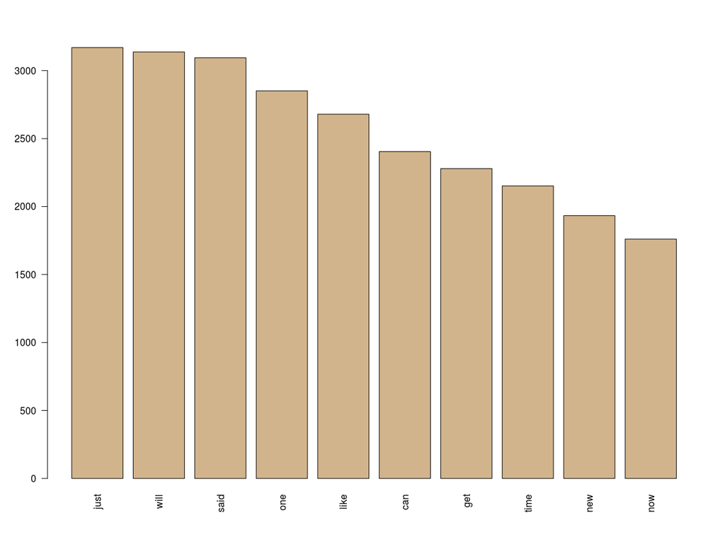

**WordCloud from Sample Dataset**

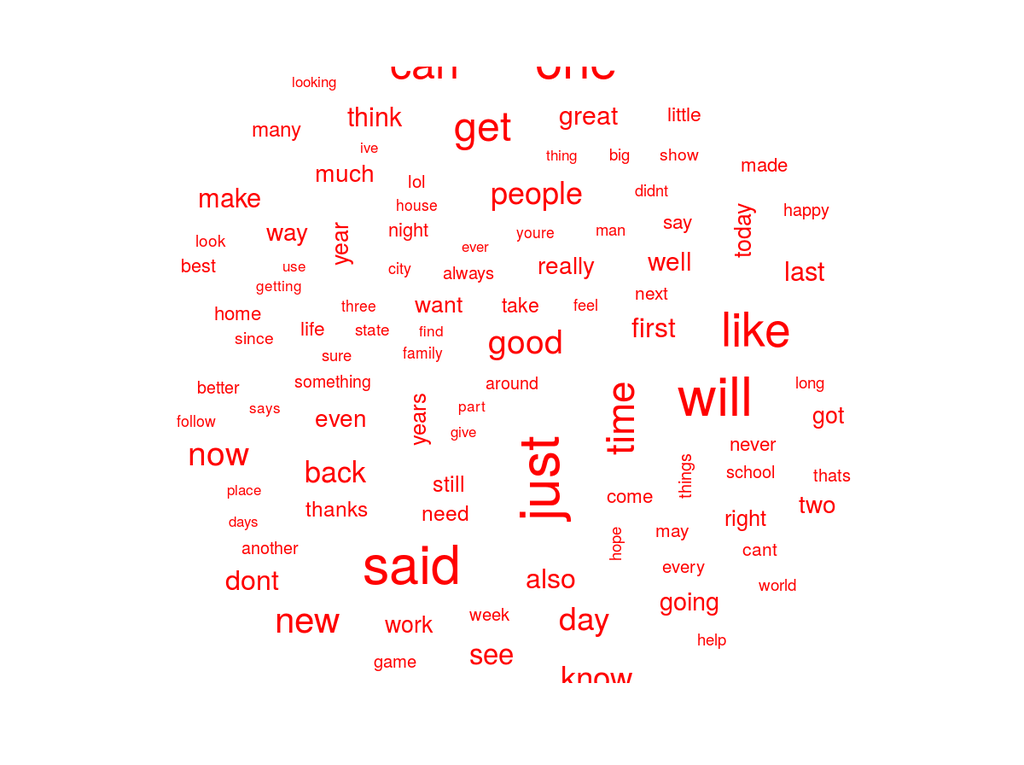

## How The Language Model will be Build

I will use so called `Stupid Backoff` n-gram Language Model to predict the next word. I will use the `Stupid Backoff` algorithym in very simple manner to improve speed and minimize complexity. I plan to use only one ngram model at a time to predict the next word; starting with the heigest n-gram model and moving to lower-ngram models if no match is found in the heighest n-gram model.

I will created a sample data set of smaller size using the orginally provided three data files. This smaller sample data set will be used for my model training.

Following steps describes how the langugae will be built:

1. Load original datafiles and create a smaller sampled dataset to be used for modeling (look `CreateSampleData.R` for details)
2. Do data exploratory analysis to look at most common words and any other data features (look at `DataPrepAndExplore.R` (This R script calculates top-words-frequncy, wordcloud, a hierarchical model of terms, calculate association between terms))
3. Take text data sample file created in the previos steps and creates 1,2,3 and 4-grams tokens of all the words in the text file.
   - Create Corpse: Corpse is a collection of documents. Created corpse using the sample data
   - Clean Corpse: Clean up corpse with punctuations, numbers, profanity and converted all words to lower case.
   - Create n-grams TDM tokens: Created 1,2,3 and 4-gram tokens TDM (Term Document Matrix) using cleaned up corpse.
   - Calculate Frequecncies: Next we calculated frequencies of each token and sorted them by higest frequency first. As sorting will help us predict the term with the higest frequncy.
   - Next we splitted tokens into individual words for that we can use 1st, 2nd and 3rd words in an N-Gram to match with input sentences.

Look at `ngrams-build.R` file for details.

4. Create a function to predict nxt word using the n-grams created in the previous steps. I created a function called `predictWord` to implement `Stupid Backoff` n-gram algorithm to predict the next word by using 4,3,2 and 1-gram models in that order. This function takes an input sentence and extracts n-1 words from that sentance. It starts with the heighest n-gram model and try to do a match. If no match is found then it looks for n-2 ngram model for a match. If no match is found in any of the n-gram model then the algorithym shows the heighest frequency word from 1-gram model.
5. Finally I created shny app which allows to input a sentence and shows predicted outcome. This shiny app loads the ngrams and the `predictWord` function created in the previous steps usning an Rdata file. Shinyapp `server.R` used the predictWord function within a reactive function to predict next word based on the input sentence provided by the `ui.R`.